# Prior specification for regression models: Reanalysis of a sleep study

# 14 Model comparison and checking

Compute LOO-CV for models 3, 4, and 5

```r
fit3 <- add_criterion(fit3, criterion = "loo", save_psis = TRUE, reloo = TRUE)
fit4 <- add_criterion(fit4, criterion = "loo", save_psis = TRUE, reloo = TRUE)
fit5 <- add_criterion(fit5, criterion = "loo", save_psis = TRUE, reloo = TRUE)
```

Compare varying intercept and slope models with normal and log-normal data models

```r
loo_compare(fit4, fit5)
```

```
 model elpd_diff se_diff p_worse diag_diff diag_elpd
  fit5       0.0     0.0      NA
  fit4     -12.2     5.0    0.99
```

Posterior predictive checking of fit4 using LOO predictive intervals

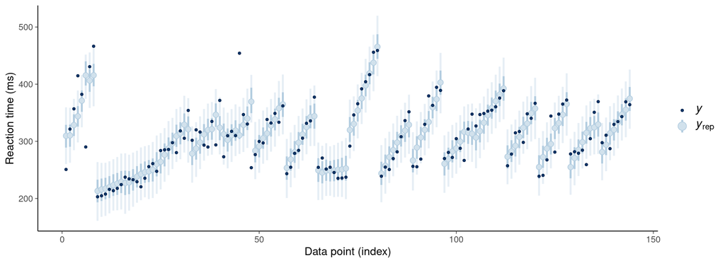

Figure 32

```r
pp_check(fit4, type = "loo_intervals") +
  labs(y = "Reaction time (ms)")
```

There are clearly some outliers.

Create varying intercept (fit3t) and varying intercept and slope (fit4t) models with Student’s $t$ data model

```r
fit3t <- update(fit3, family = student())
fit4t <- update(fit4, family = student())
```

```r
fit3t <- add_criterion(fit3t, criterion = "loo", save_psis = TRUE)
fit4t <- add_criterion(fit4t, criterion = "loo", save_psis = TRUE)
```

Posterior predictive checking of fit4t using LOO predictive intervals

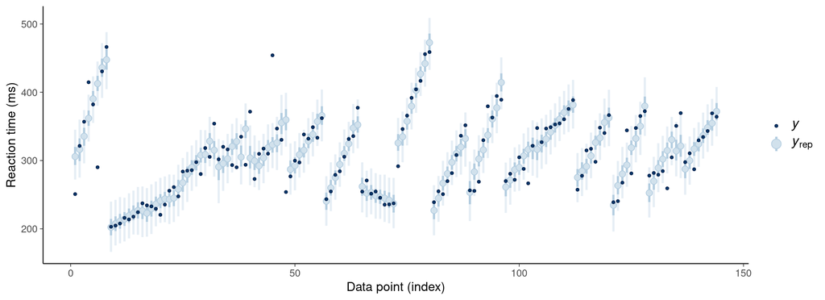

Figure 33

```r
pp_check(fit4t, type = "loo_intervals") +
  labs(y = "Reaction time (ms)")
```

The LOO predictive intervals look better now.

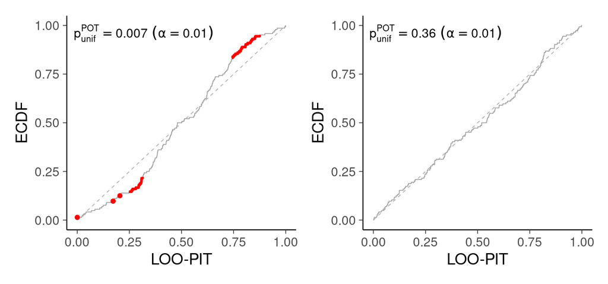

Figure 34

```r
theme_set(bayesplot::theme_default(base_family = "sans", base_size = 14))
pp_check(fit4, type = "loo_pit_ecdf", method = "correlated", moment_match = TRUE) +
  pp_check(fit4t, type = "loo_pit_ecdf", method = "correlated")
```

Looking at the LOO-PIT plots, we see that normal and log-normal models have too wide predictive distribution for most observations, which is due to a few outliers inflating the residual scale. LOO-PIT plot for Student’s $t$ model looks better. Compare normal and Student’s $t$ models

```r
loo_compare(fit4, fit4t)
```

```
 model elpd_diff se_diff p_worse diag_diff diag_elpd
 fit4t       0.0     0.0      NA
  fit4     -40.8    13.7    1.00
```

Student’s $t$ model has much better predictive performance.

Examine how much adding varying slope improved predictive performance in case of normal data model:

```r
loo_compare(fit3, fit4)
```

```
 model elpd_diff se_diff p_worse diag_diff diag_elpd
  fit4       0.0     0.0      NA
  fit3     -13.6    10.3    0.91
```

Examine how much adding varying slope improved predictive performance in case of Student’s $t$ data model:

```r
loo_compare(fit3t, fit4t)
```

```
 model elpd_diff se_diff p_worse diag_diff diag_elpd
 fit4t       0.0     0.0      NA
 fit3t     -45.6     8.6    1.00
```

When using Student’s $t$ model, the predictive performance difference between not using or using varying slope is bigger.

# References

Bates, D., M. Maechler, B. Bolker, and S. Walker. 2015. “Fitting Linear Mixed-Effects Models Using Lme4.” *Journal of Statistical Software* 67: 1–48.

Belenky, G., N. J. Wesensten, D. R. Thorne, M. L. Thomas, H. C. Sing, D. P. Redmond, M. B. Russo, and T. J. Balkin. 2003. “Patterns of Performance Degradation and Restoration During Sleep Restriction and Subsequent Recovery: A Sleep Dose-Response Study.” *Journal of Sleep Research* 12: 1–12.

# Licenses

- Code © 2025, Paul Bürkner and Aki Vehtari, licensed under BSD-3.
- Text © 2025, Paul Bürkner and Aki Vehtari, licensed under CC-BY-NC 4.0.